# Tejon_Analysis_02162021

#### **7. Model comparisons**

Tables of model summaries

```r
climate_models
```

|  | df | AIC | BIC | variables |
| --- | --- | --- | --- | --- |
| climate_gnbmod1 | 6 | 890.55 | 913.97 | maxC |
| climate_gnbmod2 | 6 | 900.84 | 924.25 | minC |
| climate_gnbmod3 | 6 | 884.76 | 908.18 | tempdiffC |
| climate_gnbmod4 | 6 | 901.01 | 924.42 | precip_mm |
| climate_gnbmod5 | 8 | 883.84 | 915.06 | Full |

```r
host_models
```

|  | df | AIC | BIC | variables |
| --- | --- | --- | --- | --- |
| host_gnb_mod1 | 6 | 902.00 | 925.42 | cum_mam |
| host_gnb_mod2 | 6 | 901.92 | 925.34 | shan_mam |
| host_gnb_mod3 | 6 | 902.11 | 925.53 | rich_mam |
| host_gnb_mod4 | 6 | 897.81 | 921.23 | liz_estimatess |
| host_gnb_mod5 | 6 | 902.10 | 925.52 | mam_estimates |
| host_gnb_mod6 | 9 | 901.96 | 937.09 | Full |

```r
combo_models
```

|  | df | AIC | BIC | variables |
| --- | --- | --- | --- | --- |
| combo_gnb_mod1 | 7 | 899.63 | 926.94 | plot |
| combo_gnb_mod2 | 6 | 895.38 | 918.80 | site |
| combo_gnb_mod3 | 6 | 884.76 | 908.18 | tempdifC |
| combo_gnb_mod4 | 6 | 897.81 | 921.23 | liz_estimates |
| combo_gnb_mod5 | 8 | 875.83 | 907.06 | tempdifC*site |
| combo_gnb_mod6 | 10 | 897.10 | 936.12 | liz_estimates*plot |

##### **7A. Summary of best fit model

```r
summary(combo_gnb_mod5)
```

```
## Generalized linear mixed model fit by maximum likelihood (Laplace
##   Approximation) [glmerMod]
##  Family: Negative Binomial(1.9274)  ( log )
## Formula: total ~ tempdifC * site + (1 | plotID) + (1 | rain_year) + (1 |
##     month)
##    Data: na.omit(FINAL)
##
##      AIC      BIC   logLik deviance df.resid
##    875.8    907.1   -429.9    859.8      358
##
## Scaled residuals:
##     Min      1Q  Median      3Q     Max
## -1.2492 -0.4337 -0.1776 -0.0188  4.9040
##
## Random effects:
##  Groups    Name        Variance Std.Dev.
##  plotID    (Intercept) 0.5272   0.7261
##  month     (Intercept) 5.5443   2.3546
##  rain_year (Intercept) 1.7635   1.3280
## Number of obs: 366, groups:  plotID, 13; month, 12; rain_year, 5
##
## Fixed effects:
##                           Estimate Std. Error z value Pr(>|z|)
## (Intercept)               -3.78801    1.62813  -2.327 0.019987 *
## tempdifC                   0.07381    0.09781   0.755 0.450504
## siteIntermediate          -3.53078    1.35559  -2.605 0.009198 **
## tempdifC:siteIntermediate  0.31165    0.09423   3.307 0.000942 ***
## ---
## Signif. codes:  0 '***' 0.001 '**' 0.01 '*' 0.05 '.' 0.1 ' ' 1
##
## Correlation of Fixed Effects:
##             (Intr) tmpdfC stIntr
## tempdifC    -0.772
## siteIntrmdt -0.368  0.463
## tmpdfC:stIn  0.443 -0.614 -0.931
```

Check model assumption https://stats.idre.ucla.edu/r/dae/negative-binomial-regression/

```r
# check residuals
# plot(combo_gnb_mod3)
#
# # best model based on parsimony is
# m1 <- glmer.nb(total ~ tempdifC + (1|plotID)+ (1|rain_year) + (1|month),
#                  data = na.omit(FINAL),
#                  family = "poisson")
# # Neg binomial models assume the conditional means are not equal to the conditional variances. This inequality is captured by estimating a dispersion parater that is held constant in a poisson model. The poisson model is actually nested int he negative binomial mode. We can use likelihood ratio test to compare thes two and test the model assumption
#
# # compare model without tempdifC to see if it is significantly different
# m2 <- update(combo_gnb_mod3, . ~ . - tempdifC)
# anova(m1, m2) # 2.716e-05, tempdiffC is a singificant predictor of total
#
# # check model assumptions
# m3 <- glm(total ~ tempdifC + site, family = "poisson", data = FINAL)
# pchisq(2 * (logLik(m1) - logLik(m3)), df = 1, lower.tail = FALSE)
#
# (est <- cbind(Estimate = coef(m1), confint(m1)))
# exp(est)
```

Predicted values

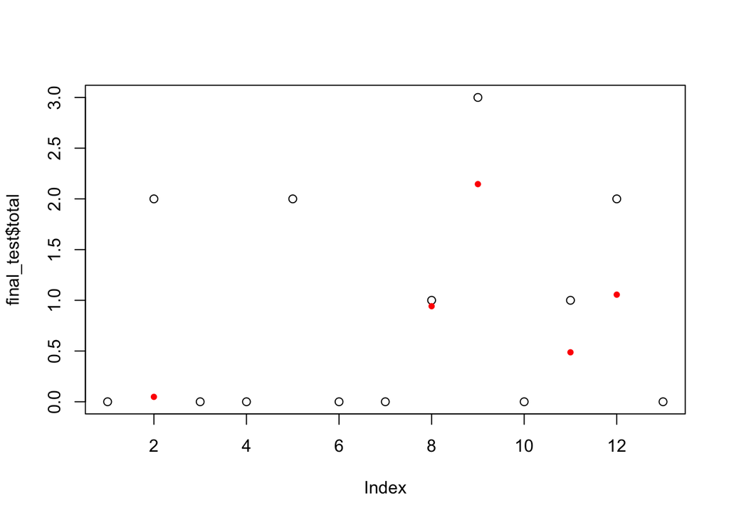

```r
## see if it can predict model
splitter <- sample(1:nrow(FINAL), 70, replace = F)
final_train <- na.omit(FINAL[-splitter,])
final_test <- na.omit(FINAL[splitter,])

final_fit <- glmer.nb(total ~ tempdifC + (1|plotID)+ (1|rain_year) + (1|month),
                 data = na.omit(FINAL),
                 family = "poisson")

prediction <- predict(final_fit, final_test)

plot(final_test$total, pch = 1)
points(prediction, pch = 20, col = "red")
```

#### **7B. Other model validation**

```r
min(FINAL$total)
```

```
## [1] NA
```

```r
model <- na.omit(FINAL)
big.model <- glm(total  ~ plot + site  + tempdifC + liz_estimates,
                 family = "poisson",
                 data = model,
                 na.action = na.pass)
library(MuMIn)
library(gtable)
sal.dredge <- dredge(big.model)
```

```
## Fixed term is "(Intercept)"
```

```r
glm.best <-model.sel(sal.dredge) %>%
  gt() %>%
  tab_header(title="all model subsets",
             subtitle = "total ~ plot + site + tempdifC + liz_estimatess")
gtsave(glm.best, "DredgeModel_BestPredictors.html")
```

**2. Relative support for each model using Akaike weight** Basically, we are comparing a set of models and want to know the probability that a model is the best model in the set. To get an Akaike weight, we can standardize the likelihood of the model:
$$w_i = \frac{exp(-\frac{1}{2}\Delta_i)}{\Sigma^R_jexp(-\frac{1}{2}\Delta_i)}$$
where $R$ is the number of models in the set, and $w_i$ is the probability that the model $i$ is the best model.

If we calculate $\Delta_i$ and $w_i$, we can compare the models.

```r
# calculate deltai2
delta1 <- exp(-0.5*(AIC(combo_gnb_mod1) - AIC(combo_gnb_mod5)))
delta2 <- exp(-0.5*(AIC(combo_gnb_mod2) - AIC(combo_gnb_mod5)))
delta3 <- exp(-0.5*(AIC(combo_gnb_mod3) - AIC(combo_gnb_mod5)))
delta4 <- exp(-0.5*(AIC(combo_gnb_mod4) - AIC(combo_gnb_mod5)))
delta5 <- exp(-0.5*(AIC(combo_gnb_mod5) - AIC(combo_gnb_mod5)))

# sum likelihoods
sum_likes <- sum(c(delta1, delta2, delta3, delta4, delta5))

# calculate weights
weight1 <- delta1/sum_likes
weight2 <- delta2/sum_likes
weight3 <- delta3/sum_likes
weight4 <- delta4/sum_likes
weight5 <- delta5/sum_likes

# lets make a table
weights <- tribble(
  ~Model,   ~Delta,           ~Weights,   ~Variable,
  "combo_gnb_mod1", round(delta1, 2), round(weight1, 2), "plot",
  "combo_gnb_mod2", round(delta2, 2), round(weight2, 2), "site",
  "combo_gnb_mod3", round(delta3, 2), round(weight3, 2), "tempdiffC",
  "combo_gnb_mod4", round(delta4, 2), round(weight4, 2), "liz estimates",
  "combo_gnb_mod5", round(delta5, 2), round(weight5, 2), "tempdiffC*site"
) %>%
  gt() %>%
  tab_style(
    style = cell_text(size = "small"),
    locations = cells_body())

weights
```

| Model | Delta | Weights | Variable |
| --- | --- | --- | --- |
| combo_gnb_mod1 | 0.00 | 0.00 | plot |
| combo_gnb_mod2 | 0.00 | 0.00 | site |
| combo_gnb_mod3 | 0.01 | 0.01 | tempdiffC |
| combo_gnb_mod4 | 0.00 | 0.00 | liz estimates |
| combo_gnb_mod5 | 1.00 | 0.99 | tempdiffC*site |

```r
# combo_gnb_mod5 has a 99% chance of being the best model
```

### **8. Additional Analyses that were used to make input variables for glmms

#### **8A. Population estimates for lizards and mammals

*Original datasets I was given: `Lizard_Counts_TREE` for lizards and `2018_smammals` and `Small_mammal_captures_19`*

From those, I created an excel sheet called `tejon_mamliz_popestimates` that I made based on the analyses in lizard estimates and mammal estimates. Yes, I know this could have been done with a for loop but couldn’t get my brain to think about it. This excel sheet is used to build the full data sheet with climate and tick counts

```r
# Used these data sheets to calculate pop estimates. All calculations used to make population estimates can be found in the dataset `tejon_mamliz_popestimates`.
### mammals
mamcounts <- read_csv("mammal_counts_02182021.csv")
dim(mamcounts) # 229   9
```

```
## [1] 229   9
```

```r
str(mamcounts)
```

```
## spec_tbl_df [229 × 9] (S3: spec_tbl_df/tbl_df/tbl/data.frame)
##  $ year : num [1:229] 2018 2018 2018 2018 2018 ...
##  $ month: chr [1:229] NA NA NA NA ...
##  $ site : chr [1:229] "Arid" "Arid" "Arid" "Arid" ...
##  $ block: num [1:229] 1 1 1 1 1 1 1 1 1 1 ...
##  $ plot : chr [1:229] "Total" "Total" "Total" "Total" ...
##  $ day1 : num [1:229] 1 1 0 0 0 0 1 1 0 0 ...
##  $ day2 : num [1:229] 1 0 1 0 0 0 0 0 1 1 ...
##  $ day3 : num [1:229] 0 0 0 1 1 1 0 0 1 0 ...
##  $ tag  : chr [1:229] "17" "94" "18" "65" ...
##  - attr(*, "spec")=
##   .. cols(
##   ..   year = col_double(),
##   ..   month = col_character(),
##   ..   site = col_character(),
##   ..   block = col_double(),
##   ..   plot = col_character(),
##   ..   day1 = col_double(),
##   ..   day2 = col_double(),
##   ..   day3 = col_double(),
##   ..   tag = col_character()
##   .. )
```

```r
mamcounts$day1 <- as.numeric(mamcounts$day1)
mamcounts$day2 <- as.numeric(mamcounts$day2)
mamcounts$day3 <- as.numeric(mamcounts$day3)
mamcounts$site <- as.factor(mamcounts$site)
mamcounts$plot <- as.factor(mamcounts$plot)
mamcounts$block <- as.numeric(mamcounts$block)
str(mamcounts)
```

```
## spec_tbl_df [229 × 9] (S3: spec_tbl_df/tbl_df/tbl/data.frame)
##  $ year : num [1:229] 2018 2018 2018 2018 2018 ...
##  $ month: chr [1:229] NA NA NA NA ...
##  $ site : Factor w/ 3 levels "Arid","Intermediate",..: 1 1 1 1 1 1 1 1 1 1 ...
##  $ block: num [1:229] 1 1 1 1 1 1 1 1 1 1 ...
##  $ plot : Factor w/ 3 levels "Open","Partial",..: 3 3 3 3 3 3 2 2 2 2 ...
##  $ day1 : num [1:229] 1 1 0 0 0 0 1 1 0 0 ...
##  $ day2 : num [1:229] 1 0 1 0 0 0 0 0 1 1 ...
##  $ day3 : num [1:229] 0 0 0 1 1 1 0 0 1 0 ...
##  $ tag  : chr [1:229] "17" "94" "18" "65" ...
##  - attr(*, "spec")=
##   .. cols(
##   ..   year = col_double(),
##   ..   month = col_character(),
##   ..   site = col_character(),
##   ..   block = col_double(),
##   ..   plot = col_character(),
##   ..   day1 = col_double(),
##   ..   day2 = col_double(),
##   ..   day3 = col_double(),
##   ..   tag = col_character()
##   .. )
```

```r
### lizards
lizcounts <- read_csv("lizardcounts_02172021.csv")
dim(lizcounts) # 1745 , 10
```

```
## [1] 1745   10
```

```r
names(lizcounts) <- tolower(names(lizcounts))

str(lizcounts)
```

```
## spec_tbl_df [1,745 × 10] (S3: spec_tbl_df/tbl_df/tbl/data.frame)
##  $ year          : num [1:1745] 2016 2016 2016 2016 2016 ...
##  $ season        : chr [1:1745] "summer" "summer" "summer" "summer" ...
##  $ month         : chr [1:1745] "July" "July" "July" "July" ...
##  $ site          : chr [1:1745] "Arid" "Arid" "Arid" "Arid" ...
##  $ block         : num [1:1745] 1 1 1 1 1 1 1 1 1 1 ...
##  $ treatment_year: num [1:1745] 0 0 0 0 0 0 0 0 0 0 ...
##  $ plot          : chr [1:1745] "Open" "Open" "Open" "Open" ...
##  $ day1          : num [1:1745] 1 1 1 1 1 1 1 1 0 0 ...
##  $ day2          : num [1:1745] 1 1 1 0 0 0 0 0 1 1 ...
##  $ day3          : num [1:1745] 1 1 1 1 1 0 0 0 1 1 ...
##  - attr(*, "spec")=
##   .. cols(
##   ..   year = col_double(),
##   ..   season = col_character(),
##   ..   month = col_character(),
##   ..   site = col_character(),
##   ..   block = col_double(),
##   ..   treatment_year = col_double(),
##   ..   plot = col_character(),
##   ..   day1 = col_double(),
##   ..   day2 = col_double(),
##   ..   day3 = col_double()
##   .. )
```

```r
lizcounts$day1 <- as.numeric(lizcounts$day1)
lizcounts$day2 <- as.numeric(lizcounts$day2)
lizcounts$day3 <- as.numeric(lizcounts$day3)
lizcounts$site <- as.factor(lizcounts$site)
lizcounts$plot <- as.factor(lizcounts$plot)
lizcounts$block <- as.numeric(lizcounts$block)
str(lizcounts)
```

```
## spec_tbl_df [1,745 × 10] (S3: spec_tbl_df/tbl_df/tbl/data.frame)
##  $ year          : num [1:1745] 2016 2016 2016 2016 2016 ...
##  $ season        : chr [1:1745] "summer" "summer" "summer" "summer" ...
##  $ month         : chr [1:1745] "July" "July" "July" "July" ...
##  $ site          : Factor w/ 3 levels "Arid","Intermediate",..: 1 1 1 1 1 1 1 1 1 1 ...
##  $ block         : num [1:1745] 1 1 1 1 1 1 1 1 1 1 ...
##  $ treatment_year: num [1:1745] 0 0 0 0 0 0 0 0 0 0 ...
##  $ plot          : Factor w/ 3 levels "Open","Partial",..: 1 1 1 1 1 1 1 1 1 1 ...
##  $ day1          : num [1:1745] 1 1 1 1 1 1 1 1 0 0 ...
##  $ day2          : num [1:1745] 1 1 1 0 0 0 0 0 1 1 ...
##  $ day3          : num [1:1745] 1 1 1 1 1 0 0 0 1 1 ...
##  - attr(*, "spec")=
##   .. cols(
##   ..   year = col_double(),
##   ..   season = col_character(),
##   ..   month = col_character(),
##   ..   site = col_character(),
##   ..   block = col_double(),
##   ..   treatment_year = col_double(),
##   ..   plot = col_character(),
##   ..   day1 = col_double(),
##   ..   day2 = col_double(),
##   ..   day3 = col_double()
##   .. )
```

```r
AridO <- lizcounts %>%
  filter(site == "Arid", plot =="Open", block == 1) %>%
  select(day1, day2, day3)

abundance0 = closedp.t(AridO, dfreq = FALSE, dtype="hist")
models <- as.data.frame(abundance0$results)
models <- models[order(models$BIC), ]

models[1,1] # select total abundance
```

```
## [1] 51.35882
```

```r
# ARID OPEN BLOCK 1 = 51.35882

AridO <- lizcounts %>%
  filter(site == "Arid", plot =="Open", block == 2) %>%
  select(day1, day2, day3)

abundance0 = closedp.t(AridO, dfreq = FALSE, dtype="hist")
models <- as.data.frame(abundance0$results)
models <- models[order(models$BIC), ]

models[1,1] # select total abundance
```

```
## [1] 60.5687
```

```r
# ARID OPEN BLOCK 2 = 60.5687

AridO <- lizcounts %>%
  filter(site == "Arid", plot =="Open", block == 3) %>%
  select(day1, day2, day3)

abundance0 = closedp.t(AridO, dfreq = FALSE, dtype="hist")
models <- as.data.frame(abundance0$results)
models <- models[order(models$BIC), ]

models[1,1] # select total abundance
```

```
## [1] 82.54301
```

```r
# ARID OPEN BLOCK 3 = 82.54301



##########################################################################
AridP <- lizcounts %>%
  filter(site == "Arid", plot =="Partial", block == 1) %>%
  select(day1, day2, day3)

abundanceP = closedp.t(AridP, dfreq = FALSE, dtype="hist")
models <- as.data.frame(abundanceP$results)
models <- models[order(models$BIC), ]

models[1,1] # select total abundance
```

```
## [1] 73.4186
```

```r
## ARID PARTIAL Block 1 = 73.4186

AridP <- lizcounts %>%
  filter(site == "Arid", plot =="Partial", block == 2) %>%
  select(day1, day2, day3)

abundanceP = closedp.t(AridP, dfreq = FALSE, dtype="hist")
models <- as.data.frame(abundanceP$results)
models <- models[order(models$BIC), ]

models[1,1] # select total abundance
```

```
## [1] 72.96941
```

```r
## ARID PARTIAL Block 2 = 72.96941

AridP <- lizcounts %>%
  filter(site == "Arid", plot =="Partial", block == 3) %>%
  select(day1, day2, day3)

abundanceP = closedp.t(AridP, dfreq = FALSE, dtype="hist")
models <- as.data.frame(abundanceP$results)
models <- models[order(models$BIC), ]

models[1,1] # select total abundance
```

```
## [1] 69.2156
```

```r
## ARID PARTIAL Block 3 = 69.2156


##########################################################################

AridT <- lizcounts %>%
  filter(site == "Arid", plot =="Total", block == 1) %>%
  select(day1, day2, day3)

abundanceT = closedp.t(AridT, dfreq = FALSE, dtype="hist")
models <- as.data.frame(abundanceT$results)
models <- models[order(models$BIC), ]

models[1,1] # select total abundance
```

```
## [1] 67.28581
```